# Basic usage

Atsushi YASUMOTO

2018-12-20

# Intro

This vignette introduce a basic procedure of analysis using `qntmap` package using example data.

See https://atusy.github.io/qntmap/#epma-analysis for preparing EPMA data.

See https://doi.org/10.2138/am-2018-6323CCBY for implementations.

# Preparation

## Load package

```r
library(qntmap)
```

## Move to working directory

```r
wd <- tempdir() # Arbitrary
setwd(wd)
```

## Copy example data

or any original data.

```r
file.copy(
  from = system.file('extdata', 'minimal', package = 'qntmap'),
  to = wd,
  recursive = TRUE
)
```

```
#> [1] TRUE
```

`TRUE` indicates files are successfully copied. Check if really files are copied by `dir()`.

```r
dir(file.path(wd, 'minimal'), recursive = TRUE, all.files = TRUE)
```

```
#>  [1] ".map/1/0.cnd"        ".map/1/1.cnd"        ".map/1/1_map.txt"
#>  [4] ".map/1/2.cnd"        ".map/1/2_map.txt"    ".qnt/.cnd/elemw.cnd"
#>  [7] ".qnt/bgm.qnt"        ".qnt/bgp.qnt"        ".qnt/elem.qnt"
#> [10] ".qnt/elint.qnt"      ".qnt/mes.qnt"        ".qnt/net.qnt"
#> [13] ".qnt/pkint.qnt"      ".qnt/stg.qnt"        ".qnt/wt.qnt"
#> [16] "README.md"
```

# Analysis

## Specify directories containing data

```r
dir_map <- 'minimal/.map/1'
dir_qnt <- 'minimal/.qnt'
```

## Load data

```r
xmap <- read_xmap(dir_map)
qnt <- read_qnt(dir_qnt, renew = TRUE)
```

This is an artifact example data which contains olivine and quartz within the mapping area. The phases are quantified 20 points each.

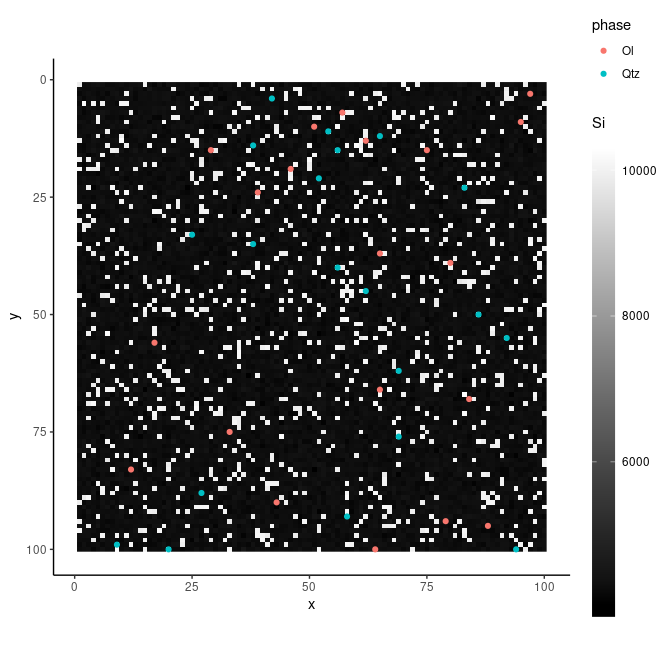

## Plot X-ray map data as heatmap

Plots are by default **interactive** with webui. Selection of elements can be done on webui.

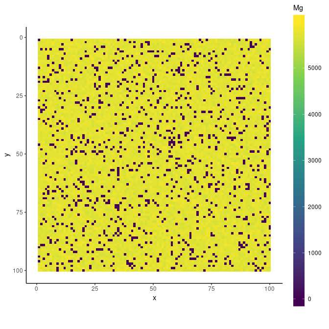

```r
plot(xmap)
# A following example is non-interactive mode run by
# plot(xmap, 'Mg', interactive = FALSE)
```

## Cluster analysis

### Initialize cluster centers

Although this step is just a guessing initialization, compare the output values with plots above to see if the centers are well guessed.

```r
centers <- find_centers(xmap, qnt)
centers
```

| phase | Si | Mg |
| --- | --- | --- |
| Ol | 4245.5 | 5726.5 |
| Qtz | 10015.5 | 0.0 |

### Run cluster analysis

The result is saved as a binary file and as png format images in `clustering` directory below the directory containing mapping data.

For a quick look, `plot()` function is also available.

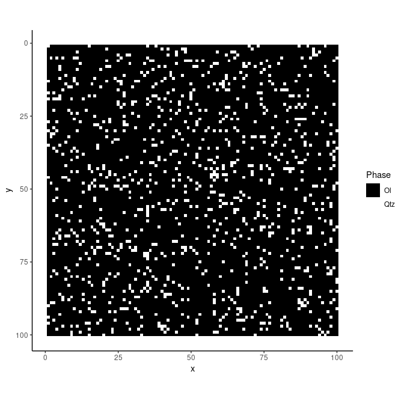

```r
cluster <- cluster_xmap(xmap, centers)
plot(cluster, interactive = FALSE)
```

### Summarize cluster analysis

`summary` function gives abundance ratios of phases in the map.

```r
summary(cluster)
```

```
#> [1] 0.90005667 0.09994333
```

## Quantify

```r
qmap <- quantify(xmap = xmap, qnt = qnt, cluster = cluster)
```

### Plot quantified map

Just like X-ray map.

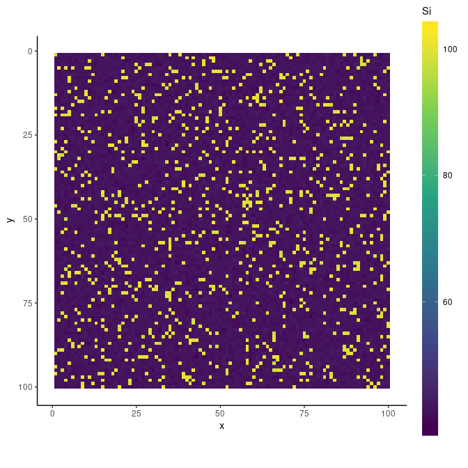

```r
plot(qmap, 'Si', interactive = FALSE)
```

### Summarize quantified map

```r
summary(qmap)
```

```
#>   Element  Min. 1st Qu. Median  Mean 3rd Qu.   Max.
#> 1      Si 40.39   42.32  42.80 48.43   43.35 102.81
#> 2      Mg  0.00   56.46  57.10 51.49   57.68  59.87
#> 3   Total 96.28   99.23  99.94 99.92  100.61 104.20
#>
#> Note that Total is not sum each column
```

Note also that this summary does not correct densities of phases.

According to compositions of olivine (57.29% MgO and 42.71 wt% SiO<sub>2</sub>), and of quartz (100% SiO<sub>2</sub>),

$$E(MgO_{bulk}) =
57.29 \times 0.9 + 0 \times 0.1 =
51.561 \simeq
51.49 \mathrm{,}$$

and

$$E(SiO2_{bulk}) =
42.71 \times 0.9 + 100 \times 0.1 =
48.439 \simeq
48.43 \mathrm{,}$$

the above summary is adequate.

### Summary based on mask images

For another way to summarize the result of quantified map, `mean` function is defined.

A simple usage gives nothing more than `mean` column of `summary()`.

```r
mean(qmap)
```

| Element | Whole area |
| --- | --- |
| Si | 48.43476 |
| Mg | 51.48943 |
| Total | 99.92420 |

However, by using mask image, `mean` values of each element are calculated for each mask areas with same colors.

Let’s use an image from cluster analysis above.

Input path to the image to `segment` function.

```r
i <- segment(dir("/tmp/RtmpqFUESS/minimal/.map/1/clustering/181220_1155_pois_k2_SiMg_map.png"))
```

Then, input the result of `segment()` to `index` parameter of `mean()`.

```r
mean(qmap, index = i)
```

| Element | #000000 | #FFFFFF |
| --- | --- | --- |
| Si | 42.71445 | 99.91755 |
| Mg | 57.21048 | 0.00000 |
| Total | 99.92493 | 99.91755 |

As black (`#000000`) corresponds to olivine cluster, and white (`#FFFFFF`) corresponds to quartz cluster, the average compositions of each clusters are nearly equal to ideal compositions of olivine and quartz.

This feature is useful to find average compositions of each minearls, local bulk compositions of domains (layer, symplectite, and so on).

Note that mask image must be have **same width and height** as mapping data, and should be either `bmp` or `png` format. `jpg` is allowed but not recommended as it is a lossy format.